# Diversity, Equity, Inclusion, and Justice

Week 5 Monday — Who is recognized in a conservation decision?

NRES 315: Human Dimensions of Fish and Wildlife Management

2026-09-20

## Why this comes after evidence and learning

Week 4 asked how a management problem is framed, how evidence enters a plan, and how monitoring changes the next cycle.

This week asks the prior question: **who is in that process, whose knowledge is taken seriously, and who is able to influence the result?**

Source: Chapter 4, §4.2

## Today’s question

How do diversity, equity, inclusion, and justice shape whether a conservation decision is legitimate and durable?

Source: Chapter 4, §4.1

## What you should be able to do

By the end of today, you should be able to:

- distinguish diversity, equity, inclusion, and justice;
- explain why representation, capacity, and relevancy matter to the profession;
- tell the difference between presence in a process and influence over it; and
- name one guideline for working across knowledge traditions.

Source: Chapter 4, §§4.2–4.5

## Justice is a management condition

Access, influence, and recognition shape whether a conservation decision can be publicly legitimate.

Source: Chapter 4, §4.2

## DEIJ is part of management practice

DEIJ shapes:

- access to land and water;
- whose knowledge is recognized;
- who bears costs and receives benefits; and
- who has influence in public processes.

Source: Chapter 4, §4.2

## Four related terms

- **Diversity:** varying attributes within a community.
- **Equity:** fair opportunity to engage and benefit, including attention to barriers.
- **Inclusion:** being accepted, supported, and able to contribute.
- **Justice:** fair practices that dismantle barriers and enable full participation.

Source: Chapter 4, Table 4.1

## The four terms are not interchangeable

Institutions are sometimes criticized for emphasizing diversity and inclusion, which are more widely accepted, while avoiding the deeper questions of equity and justice that challenge existing power structures.

Source: Chapter 4, §4.4

## Why DEIJ matters to the profession

Chapter 4 gives three practical reasons:

- **capacity:** who enters, stays, and leads in the profession;
- **representation:** whether the profession reflects the publics it serves; and
- **relevancy:** whether conservation institutions can respond to changing communities, values, and relationships with nature.

Source: Chapter 4, §§4.3.1–4.3.3

## A “first” is rarely enough

Numerical representation does not always translate into organizational influence.

- Organizations need a **critical mass** of diverse voices to support innovation and belonging.
- Critical mass may still fail to change direction unless people reach **formal leadership roles**.
- Without sustained change, people experience **tokenism**: inclusion as a symbolic representative rather than as a full participant.

Source: Chapter 4, §4.4.1

## Internal and external DEIJ work

**Internal**

Hiring, retention, leadership development, workplace culture, institutional policy. Often top-down.

**External**

How agencies work with publics, communities, Indigenous nations, and partners. Often bottom-up, driven by publics asserting rights, values, and knowledge.

Both face real constraints. Both are necessary.

Source: Chapter 4, §4.4

## The 2025 executive orders

[figure not shown]

EO 14151 and EO 14148, both signed January 20, 2025. An executive order directs the **executive branch**; it is not a statute or a court ruling.

Source: Chapter 4, §4.4; Chapter 5, §5.5.1

## What it means for fish and wildlife

Chapter 4 reports three effects on the profession: DEI-related **programs were suspended** across executive-branch agencies; restrictions on university programming affect the **workforce pipeline**; and TWS noted that **layoffs of early-career professionals** may hinder management of public lands and trust resources.

The profession adopted its own position first. TWS’s workforce-diversity position statement dates to **October 2020**, and argues from management effectiveness: engaging a greater proportion of the population lets us “more effectively manage wildlife, the ecosystems on which they depend, and the human communities that interact with them.”

Source: Chapter 4, §4.4; Arnett et al. 2025; Rodgers and Arnett 2025; TWS Position Statement on Workforce Diversity (2020)

## Presence is not influence

A process can include people without sharing influence.

Source: Chapter 4, §4.4.2

## Presence only, or meaningful inclusion?

**Presence only**

People are invited, but barriers limit their participation or their knowledge has no effect on the decision.

**Meaningful inclusion**

Relevant publics can participate, their knowledge is recognized, and the process makes clear how their input can affect the decision.

Source: Chapter 4, §§4.2–4.3

## Participation has to be designed, not announced

- Identify affected publics and barriers to access.
- Engage **early enough** for input to shape the problem and the alternatives.
- Explain the **scope of influence** and how input was used.
- Build collaboration and accountability into the continuing relationship.

Source: Chapter 4, §4.4.2

## When a process is seen as exclusionary

Publics use many routes to assert influence: activism, protest, media, lobbying, public comment, public relations, and community organizing.

Bottom-up participation is often a response to a process that did not share influence in the first place.

Source: Chapter 4, §4.4.2

## Protected areas show the stakes

Protected areas established without local consent often lack enduring public and political support. They can become:

- vulnerable to **PADDD** — downgrading, downsizing, and degazettement; or
- **“paper parks”** that exist on a map but lack the legitimacy needed for actual protection.

Source: Chapter 4, §4.4.2

## Grand Staircase–Escalante

- Designated in 1996 to protect an ecologically rich landscape.
- Many local communities and Indigenous nations felt they were **not sufficiently consulted**.
- Reduced by nearly 50% in 2017 through executive action.
- Critics point to the lack of local engagement and long-term political consensus as key factors.

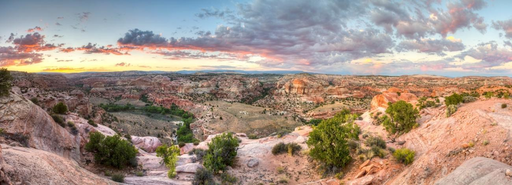

Instructional content: Chapter 4, §4.4.2. Illustrative image: [Bureau of Land Management](https://www.blm.gov/programs/national-conservation-lands/utah/grand-staircase-escalante-national-monument).

## The other direction: reasserting local control

Communities also use protected areas to reassert authority and sustain relationships:

- Grand Portage Band of Lake Superior Chippewa comanaging a national monument with the National Park Service;
- transfer of the National Bison Range to the Confederated Salish and Kootenai Tribes; and
- the Indigenous Circle of Experts in Canada.

Source: Chapter 4, §4.4.2

## Box 4.3 — Salmon justice

For more than a century, Tribes in the Pacific Northwest have fought for the right to harvest salmon and steelhead and to sustain their communities around these fisheries.

- Timber, mining, agriculture, hydropower, and commercial fishing transformed the rivers and devastated the runs.
- Losses were ecological, economic, **cultural, and spiritual** — salmon is a primary “first food.”
- Because many Tribal members eat more locally caught fish, contaminant risk can exceed what regulatory standards assume.
- A 2023 federal settlement shifted control of restoration funds toward Tribal governments.

Source: Chapter 4, Box 4.3

## Knowledge traditions

Disciplines, fields of study, and intergenerational ways of knowing that shape how people relate to the natural world.

Source: Chapter 4, §4.5

## The Six Rs

Many North American Indigenous knowledge systems summarize their research and relationship principles as:

**respect · relationship · relevance · reciprocity · responsibility · representation**

Source: Chapter 4, §4.5.1.1

## Work across knowledge traditions with humility

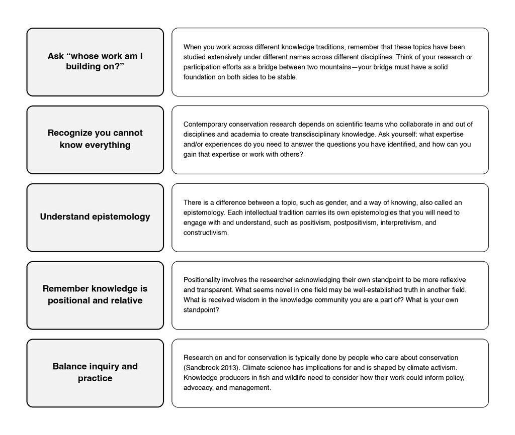

Source: Chapter 4, Figure 4.1

## The same guidelines, in words

- Identify whose work and knowledge you are building on.
- Recognize the limits of your expertise.
- Understand epistemology — how a tradition decides what counts as knowing.
- Remember that knowledge is positional and relative.
- Balance inquiry with practice.

This is a practice standard, not an invitation to treat every knowledge claim as interchangeable.

## Pair rehearsal: presence or influence?

With a partner, take one of these and decide whether it is **presence only** or **meaningful inclusion**, and say what would have to change:

1. A 30-day comment period on a completed draft plan.
2. A standing basin council that sets its own agenda but cannot decide.
3. A comanagement agreement that gives a sovereign partner a decision role.

## Wednesday and Friday

**Wednesday:** Chapter 5 — the governance machinery that decides who *can* share influence, and what it costs.

**Before Friday:** read the **Week 05 Case Brief: the Cottonwood River Access and Restoration Plan**. It is a separate document in the Canvas module and is required preparation.

Source: Chapters 4–5

## Close: a management standard

Conservation decisions are more durable when they are ecologically sound **and** publicly accountable to diverse publics, authorities, and contexts.

Source: Chapter 4, §4.6